# SAE 5-03 Mise en oeuvre d’un processus Data Mining

2024-01-15

### Sleep Health

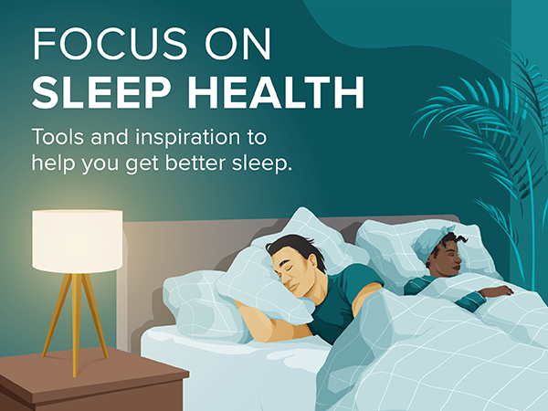

Lors de cette SAE 5-03 Mise en oeuvre d’un processus Data Mining, nous appliquerons certaines notions étudiées lors des cours de datamining de 2ème année et troisième année de BUT Science des Données. Nous commencerons par appliquer une classification à nos données, puis par effectuer une Analyse Factorielle des Correspondances (AFC) et enfin nous appliquerons une procédure d’apprentissage automatique

### Présentation des variables:

Colonnes du jeu de données :

ID de la personne : Un identifiant pour chaque individu.

Genre : Le genre de la personne (Homme/Femme).

Âge : L’âge de la personne en années.

Profession : La profession ou le métier de la personne.

Durée du sommeil (heures) : Le nombre d’heures de sommeil par jour.

Qualité du sommeil (échelle : 1-10) : Une évaluation subjective de la qualité du sommeil, allant de 1 à 10.

Niveau d’activité physique (minutes/jour) : Le nombre de minutes que la personne consacre à une activité physique quotidienne.

Niveau de stress (échelle : 1-10) : Une évaluation subjective du niveau de stress vécu par la personne, allant de 1 à 10.

Catégorie de l’IMC : La catégorie de l’IMC de la personne (p. ex., sous-poids, normal, surpoids).

Pression artérielle (systolique/diastolique) : La mesure de la pression artérielle de la personne, indiquée par la pression systolique sur la pression diastolique.

Fréquence cardiaque (bpm) : La fréquence cardiaque au repos de la personne en battements par minute.

Pas quotidiens : Le nombre de pas que la personne fait par jour.

Trouble du sommeil : La présence ou l’absence d’un trouble du sommeil chez la personne (Aucun, Insomnie, Apnée du sommeil).

```r
X=read.delim("Sleep_health_and_lifestyle_dataset.csv" , header=TRUE,sep=",",dec=".")
```

Nous allons tout d’abord regarder si notre jeu de données contient des NA avec la commande :

```r
sum(is.na(X))
```

```
## [1] 0
```

Le jeu de données ne contient aucune NA.

Nous enlevons ensuite les variables qualitatives afin de pouvoir faire la classification.

```r
X=X[,-2]
X=X[,-3]
X=X[,-7]
X=X[,-10]
```

```r
X=X[,-7]
```

### Classication

L’objectif de la classification est de regrouper des individus, ou des variables, en un nombre limité de groupes, de classes. L’ensemble de ces classes forme une partition de la population.

Une première méthode de classification est la classification hiérarchique.

On centre et réduit le fichier.

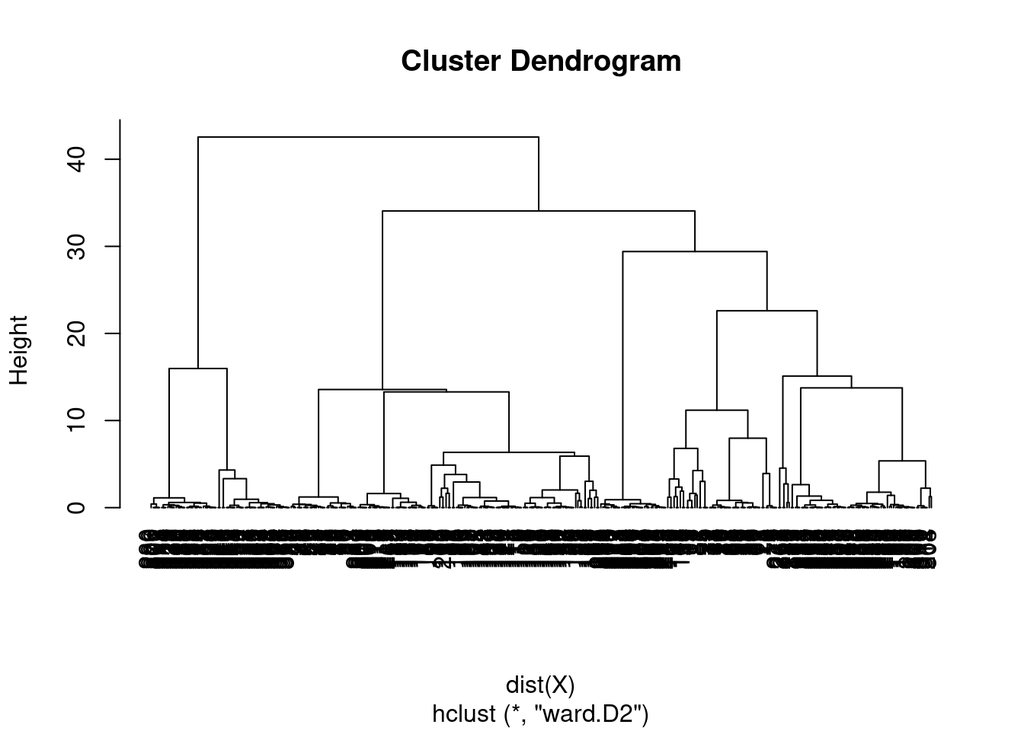

```r
X=scale(X)

cah = hclust(dist(X),method="ward.D2")

plot(cah, hang = -1)
```

On obtient grâce à hclust le dendrogramme ci-dessus. Le Dendrogramme est le type de diagramme en arborescence que l’on utilise pour présenter le clustering hiérarchique, à savoir les relations entre des ensembles de données similaires. L’analyse d’un dendrogramme permet d’identifier les regroupements naturels, d’évaluer la structure hiérarchique des données et de comprendre les relations de parenté entre les différentes entités. En examinant les coupures horizontales du dendrogramme, on peut déterminer le nombre optimal de clusters, facilitant ainsi la segmentation des données en fonction de leurs similitudes. La lecture du dendrogramme ci-dessus nous permet d’établir que le nombre de classes optimal q serait de 5.

Nous allons à présent utiliser une autre méthode. La méthode du coude va pouvoir nous permettre de s’assurer que le nombre de classes optimal est 5.

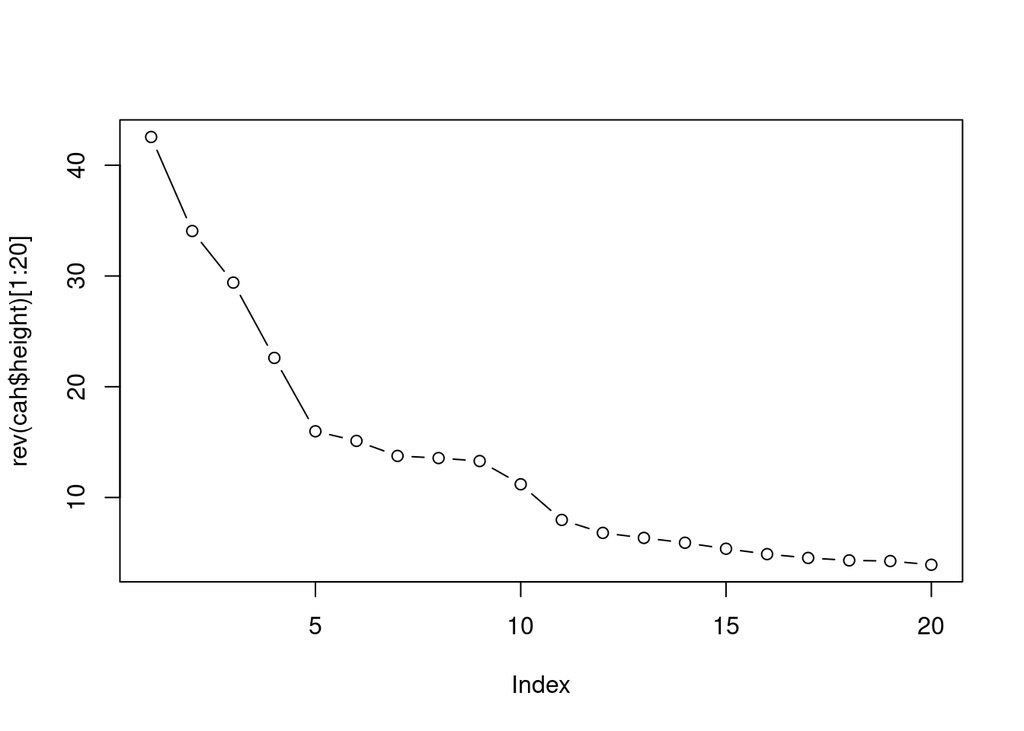

```r
plot(rev(cah$height)[1:20],type="b")
```

Dans ce graphique, on observe a un coude à q = 5. C’est le point où le total dans la somme des carrés commence à se stabiliser.

Grâce au dendogramme et à la méthode du coude on peut alors établir avec certitude que le meilleur nombre de classes optimal est de 5.

On affiche alors ces 5 classes sur le dendogramme ci-dessous en rouge:

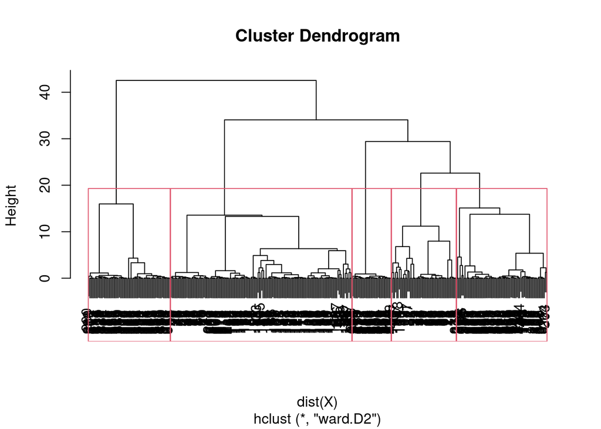

```r
q=5
plot(cah)
rect.hclust(cah, q)
```

### Analyse en Composantes Principales (ACP)

En réduisant le nombre de dimensions, l’ACP facilite la visualisation des relations entre les observations, mettant en évidence les tendances, les clusters et les schémas sous-jacents. Les composantes principales sont ordonnées en fonction de la quantité de variance qu’elles expliquent, permettant ainsi de sélectionner les dimensions les plus significatives.

Il s’agit donc de résumer l’information qui est contenue dans notre jeu de données en un certain nombre de variables synthétiques appelées : Composantes principales.

```r
classif=cutree(cah,q)
n=length(classif)
variance_totale=sum(diag(var(X)))*(n-1)/n
variances_classes=rep(0,q)
for (k in 1:q) {
  n=sum(classif==k)
  variances_classes[k] = sum(diag(var(X[classif==k,])))*(n-1)/n
}

round(variances_classes,2)
```

```
## [1] 2.90 1.78 3.36 0.03 2.16
```

```r
round(variance_totale,2)
```

```
## [1] 7.98
```

```r
round(sqrt(variances_classes),2)
```

```
## [1] 1.70 1.33 1.83 0.16 1.47
```

```r
round(sqrt(variance_totale),2)
```

```
## [1] 2.82
```

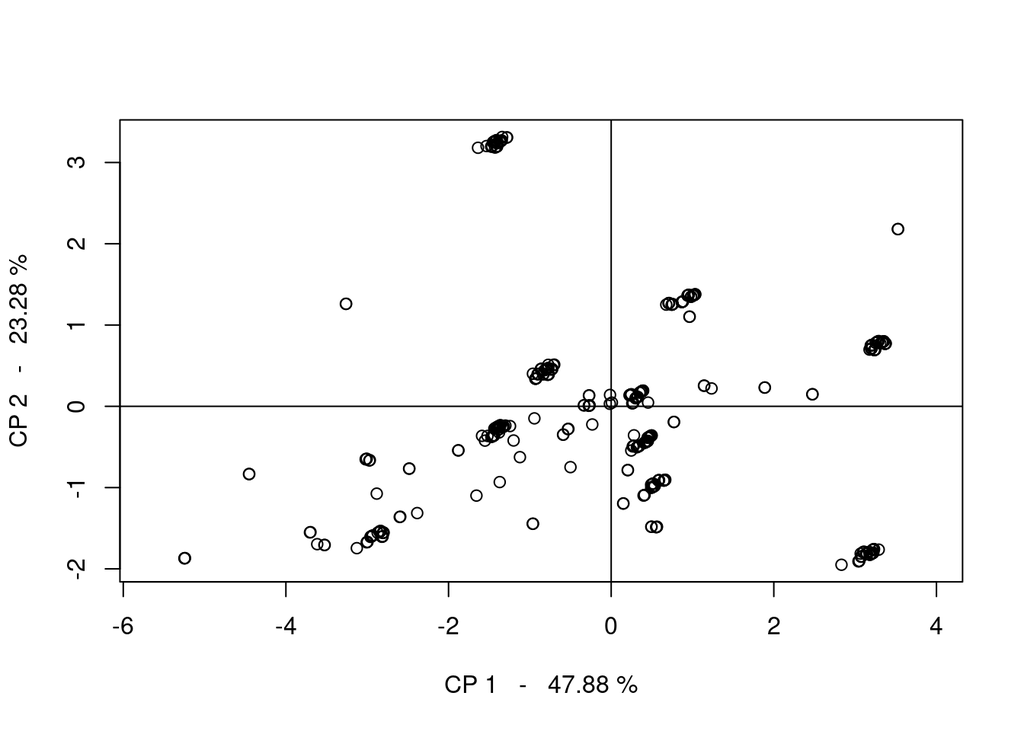

```r
X=as.matrix(X)

if (sum(ls()=="L")==0) L=2
n=nrow(X)
p=ncol(X)

X=scale(X)*sqrt(n/(n-1))

V=cor(X)
d=eigen(V,symmetric=T)
# all equal
for (j in 1:p) d$vectors[,j]=ifelse(d$vectors[1,j]>0,1,-1)*d$vectors[,j]

cp=X%*% d$vectors
colnames(cp)=paste("cp",1:p,sep="")

contributions=d$values


############################################################################
#   Graphe des composantes principales (Vue de l'ACP)
#       Representation simultanee
############################################################################

plot(cp[,1],cp[,2],
xlab=paste("CP 1   -   ",round(100*contributions[1]/p,2)," %",sep=""),
ylab=paste("CP 2   -   ",round(100*contributions[2]/p,2)," %",sep=""),asp=1)
abline(h=0,v=0)
# symbols(0,0,circles=c(1),add=TRUE,inches=FALSE)
text(cp[,1],cp[,2],rownames(X),pos=3,cex=0.7,xpd=NA)
```

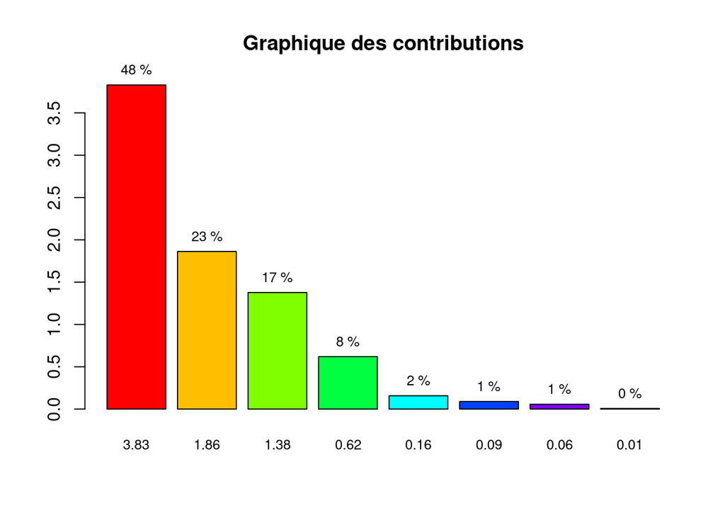

```r
#
cor_var_init_cp= d$vectors %*% diag(sqrt(d$values))
rownames(cor_var_init_cp)=colnames(X)
colnames(cor_var_init_cp)=paste("cp",1:p,sep="")
write.table(round(cor_var_init_cp,2),"cor_var_init_cp.txt",row.names=T,col.names=T,sep=" ",quote=F)
#View(round(cor_var_init_cp,2))
write.table(data.frame(round(cor_var_init_cp,2)), "cor_var_init_cp.csv", sep = ";", col.names = NA)

#arrows(0,0,cor_var_init_cp[,1]*L,cor_var_init_cp[,2]*L,col="red",length=0.1)
#text(cor_var_init_cp[,1]*L*1.1,cor_var_init_cp[,2]*L*1.1,colnames(X),cex=0.8,col="red",xpd=NA)


############################################################################
#   -- Cercle des correlations --
############################################################################
#
# plot(cor_var_init_cp[,1],cor_var_init_cp[,2],asp=1,main="Cercle des correlations",xlim=c(-1,1),ylim=c(-1,1),xlab="cp1",ylab="cp2")
# abline(h=0,v=0)
# symbols(0,0,circles=c(1),add=TRUE,inches=FALSE)
# symbols(0,0,circles=c(0.75),add=TRUE,inches=FALSE)
#
# arrows(0,0,cor_var_init_cp[,1],cor_var_init_cp[,2],col="red",length=0.1)
# text(cor_var_init_cp[,1]*1.1,cor_var_init_cp[,2]*1.15,colnames(X),cex=0.8,col="red",xpd=NA)

############################################################################
#   -- Graphique des contributions --
############################################################################
par(mfrow=c(1,1))
g=barplot(contributions,main="Graphique des contributions",
names.arg=round(contributions,2),col=rainbow(p),cex.names = 0.8)
text(g,contributions,paste(round(100*contributions/p),"%"),pos=3,cex=0.8,xpd=NA)
```

```r
# abline(h=100/p,lty=2)
#
```

On obtient le graphe des contributions. Celui-ci affiche les variances des composantes principales. Ici on observe 3 composantes principales ayant une variance significativement supérieure à 1. Elles sont donc plus informatives que les variables initiales. Ce sont ce qu’on appelle des super-variables. Lorsque l’on se reporte au tableau de corrélations :

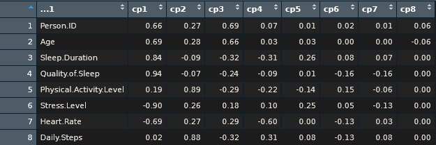

On relève une première corrélation sur la durée du sommeil et sa qualité et une deuxième corrélation négative sur le taux de stress et la fréquence cardiaque. La seconde composante principale retient 23% de l’information initiale. Lorsque l’on se reporte au tableau de corrélations on relève une unique corrélation avec le nombre de pas et l’activité physique.

### Silhouette

On appelle silhouette en classification une mesure : -de la position d’un individu dans sa classe, -de sa position par rapport aux autres classes, -mais aussi des positions des classes entre elles -mais aussi la qualité globale de la classification

Voyons donc si notre classification est de bonne qualité.

[figure not shown]

```r
classif=cutree(cah,q)
library(cluster)
sil = silhouette(classif, dist(X))
plot(sil , nmax=180 , cex.names=0.5)
```

Sur ce graphique, on observe qu’aucun point doit être reclassé. Le score silhouette de la classe 1 est situé à 0.43 ce qui signifie que la classification est médiocre. Le score silhouette de la classe 2 est situé à 0.48 ce qui signifie que la classification est également médiocre. Le score silhouette de la classe 3 est situé à 0.33 ce qui signifie que la classification est également médiocre. Le score silhouette de la classe 4 est situé à 0.95 ce qui signifie que la classification est bonne. Le score silhouette de la classe 5 est situé à 0.60 ce qui signifie que la classification est correcte.

Dans la globalité, la moyenne des scores silhouettes de chaque classe se situe à 0.51, donc on peut en conclure que la classification effectuée est correcte.

Pour aller plus loin dans cette classification, on peut établir le profil type des 5 classes.

```r
moyennes= aggregate(X,list(classif),mean)[,-1]
round(moyennes,2)
```

```
##   Person.ID   Age Sleep.Duration Quality.of.Sleep Physical.Activity.Level
## 1     -1.18 -1.15          -1.23            -1.35                   -1.19
## 2     -0.63 -0.62           0.42             0.38                    0.51
## 3      0.44  0.29          -0.66            -0.59                   -0.59
## 4      0.90  0.87          -1.34            -1.10                    1.48
## 5      1.41  1.53           1.41             1.41                   -0.25
##   Stress.Level Heart.Rate Daily.Steps
## 1         1.27       1.07       -0.95
## 2        -0.26      -0.28        0.44
## 3         0.18       0.07       -0.63
## 4         1.48       1.17        1.97
## 5        -1.33      -0.86       -0.46
```

```r
round(dist(moyennes),2)
```

```
##      1    2    3    4
## 2 3.91
## 3 2.88 2.60
## 4 4.92 4.28 3.90
## 5 6.34 3.70 3.75 5.96
```

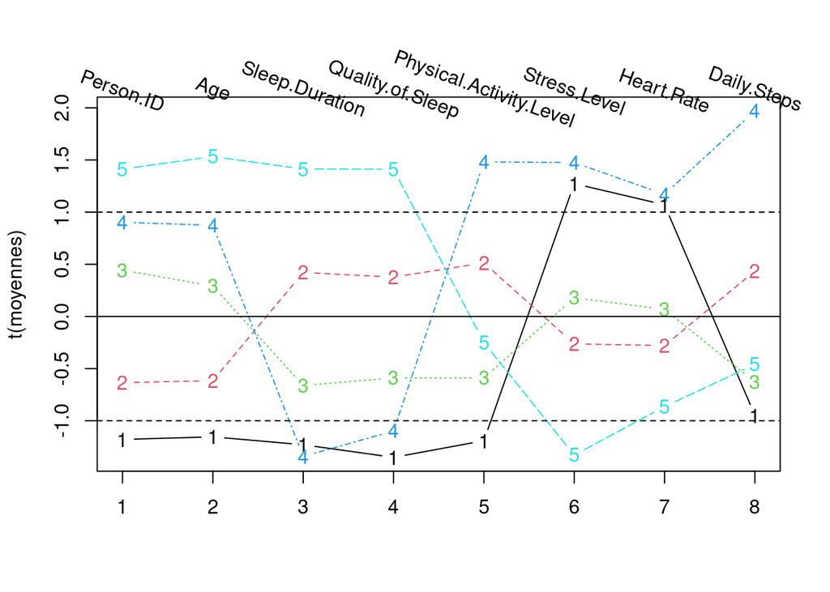

```r
matplot(t(moyennes),type="b")
abline(h=0)
abline(h=c(-1,1),lty=2)
text(1:ncol(X),max(moyennes)*1.1,colnames(X),xpd=NA,srt=-20)
```

Interprétation :

La classe 1 regroupe les personnes ayant une moyenne d’âge inférieure à la moyenne, qui une qualité de sommeil, une durée de sommeil ainsi qu’un taux d’activité physique et de pas dans la journée très inférieure à la moyenne. On remarque que cette classe a un taux de stress et une fréquence cardique élévée.

La classe 2 est la classe qui reste le plus dans la moyenne. Elle est composée d’une groupe de personne ayant un age inférieur à la moyenne. Sa qualité de sommeil, sa durée de sommeil et son taux d’activité physique est supérieur à la moyenne, son niveau de stress inférieur.

La classe 3 est l’opposé de la classe 2 symétriquement à la moyenne.

La classe 4 dort peu et à une mauvaise qualité de sommeil, elle stresse beaucoup et pratique une activité physique.

On remarque que la quantité et la qualité du sommeil est bien meilleure pour la classe 5, la classe la plus agée. Cette classe a un taux de stress et un rythme cardiaque bien plus bas que la moyenne.

### AFC

```r
X=read.delim("Sleep_health_and_lifestyle_dataset.csv" , header=TRUE,sep=",",dec=".")
```

```r
X = X[,c(4,13)]
```

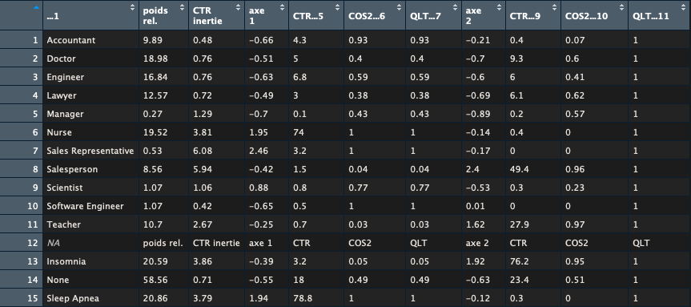

```r
library(ade4)

msg=""
if ((ncol(X) != 2) | (is.numeric(X[1,1]))) {
  msg=readline("Format tableau de contingences ? o/n : ")
}
if (msg=="o"){
  X_tab_cont=X
  rownames(X_tab_cont)=X_tab_cont[,1]
  X_tab_cont=X_tab_cont[,-1]
} else {
  for (j in 1:ncol(X)) X[,j]=as.factor(X[,j])
  Z=matrix(table(X[,1],X[,2]),nlevels(X[,1]),nlevels(X[,2]))
  rownames(Z)=levels(X[,1])
  colnames(Z)=levels(X[,2])
  X_tab_cont=Z
  rm(Z)
}

n=nrow(X_tab_cont);p=ncol(X_tab_cont)

############################################################################
#   -- L'instruction dudi.coa           ?dudi.coa
############################################################################

afc = dudi.coa( X_tab_cont , scannf = TRUE)
kept_axes =afc$nf

############################################################################
#   -- GRAPHIQUES
############################################################################

### Histogramme des valeurs propres
contributions=afc$eig/sum(afc$eig)
g=barplot(afc$eig,main="Graphique des contributions",col="orange")
text(g,afc$eig,labels=paste(round(100*contributions,2),"%"),pos=3,xpd=NA)

### Vue
if (kept_axes>=2){
  P=apply(X_tab_cont,2,sum)/sum(X_tab_cont)

  plot(afc$c1[,1:2],
  xlim=range(c(afc$c1[,1],afc$l1[,1])),
  ylim=range(c(afc$c1[,2],afc$l1[,2])),
  cex=p*P*2,pch=2,
  xlab=paste("Facteur 1   -   ",round(100*contributions[1],2)," %",sep=""),
  ylab=paste("Facteur 2   -   ",round(100*contributions[2],2)," %",sep=""))

  text(afc$c1[,1:2],labels=colnames(X_tab_cont),cex=0.75,
  font=2,pos=3,xpd=NA)

  abline(h=0,v=0,col="black")

  P=apply(X_tab_cont,1,sum)/sum(X_tab_cont)
  points(afc$l1[,1:2],cex=n*P*2,col="red")
  text(afc$l1[,1:2],labels=rownames(X_tab_cont),cex=0.75,
  font=3,pos=3,xpd=NA,col="red")
}

############################################################################
#   -- TABLEAUX D'INTERPRETATION
############################################################################

inerties = inertia.dudi(afc, col=TRUE, row=TRUE )

######################################################################
#
#   -- exportation des donnees
#
######################################################################

nomFic="tableau_interpretation_AFC.csv"
nomFicComplet=paste(getwd(),"/",nomFic,sep="")

######################################################################
#                   -1 modalites-lignes
######################################################################

contribution=round(100*inerties$row.abs/apply(inerties$row.abs,2,sum),1)
v=abs(inerties$row.rel[,1:kept_axes])
if (kept_axes==1) cosinus_carre = matrix(round(v/sum(v),2),length(v),1) else cosinus_carre=round(v/apply(v,1,sum),2)

M = matrix(0 , n , 2+4*kept_axes )

for (i in 1:n) {
    M[i,1] = round(100*sum(X_tab_cont[i,])/sum(X_tab_cont),2)
    M[i,2] = round(sum(afc$l1[i,]^2),2)
    for (j in 1:kept_axes) {
    M[i,3+(j-1)*4] = round(afc$l1[i,j],2)
    M[i,4+(j-1)*4] = contribution[i,j]
    M[i,5+(j-1)*4] = cosinus_carre[i,j]
    M[i,6+(j-1)*4] = sum(cosinus_carre[i,1:j])
    }
}

D=data.frame(M)
rownames(D)=rownames(X_tab_cont)  ;  colnames(D)[1:2]=c("poids rel.","CTR inertie")
for (j in 1:kept_axes) {
    colnames(D)[3+(j-1)*4] = paste("axe ",j,sep="")  ;  colnames(D)[4+(j-1)*4] = "CTR"
    colnames(D)[5+(j-1)*4] = "COS2"  ;  colnames(D)[6+(j-1)*4] = "QLT"
}

entete=matrix(c(" ",colnames(D)),1,ncol(D)+1)
write.table(entete,nomFicComplet,sep=";",quote=FALSE,row.names=FALSE,col.names=FALSE)

D1=D
write.table(D1,nomFicComplet,sep=";",quote=FALSE,row.names=TRUE,col.names=FALSE,append=TRUE)
write.table(" ",nomFicComplet,sep=";",quote=FALSE,row.names=FALSE,col.names=FALSE,append=TRUE)

######################################################################
#                   -2 modalites-colonnes
######################################################################

contribution=round(100*inerties$col.abs/apply(inerties$col.abs,2,sum),1)
v=abs(inerties$col.rel[,1:kept_axes])
if (kept_axes==1) cosinus_carre = matrix(round(v/sum(v),2),length(v),1) else cosinus_carre=round(v/apply(v,1,sum),2)

M = matrix(0 , p , 2+4*kept_axes )

for (i in 1:p) {
    M[i,1] = round(100*sum(X_tab_cont[,i])/sum(X_tab_cont),2)
    M[i,2] = round(sum(afc$c1[i,]^2),2)
    for (j in 1:kept_axes) {
    M[i,3+(j-1)*4] = round(afc$c1[i,j],2)
    M[i,4+(j-1)*4] = contribution[i,j]
    M[i,5+(j-1)*4] = cosinus_carre[i,j]
    M[i,6+(j-1)*4] = sum(cosinus_carre[i,1:j])
    }
}

D=data.frame(M)
rownames(D)=colnames(X_tab_cont)  ;  colnames(D)[1:2]=c("poids rel.","CTR inertie")
for (j in 1:kept_axes) {
    colnames(D)[3+(j-1)*4] = paste("axe ",j,sep="")  ;  colnames(D)[4+(j-1)*4] = "CTR"
    colnames(D)[5+(j-1)*4] = "COS2"  ;  colnames(D)[6+(j-1)*4] = "QLT"
}
D2=D
write.table(entete,nomFicComplet,sep=";",quote=FALSE,row.names=FALSE,col.names=FALSE,append=TRUE)
write.table(D2,nomFicComplet,sep=";",quote=FALSE,row.names=TRUE,col.names=FALSE,append=TRUE)
```

[output not shown]

Pour interpréter ce tableau on selectionne les lignes ayant des valeurs supérieures à 0.70 dans la colonne COS2 et ayant un CTR élévé. On observe ensuite si la valeur de l’axe est négative ou positive.

### Machine learning

```r
M=read.delim("Sleep_health_and_lifestyle_dataset.csv" , header=TRUE,sep=",",dec=".")
m = M[,c(6,7,8,9)]
str(m)
```

```
## 'data.frame':    374 obs. of  4 variables:
##  $ Quality.of.Sleep       : int  6 6 6 4 4 4 6 7 7 7 ...
##  $ Physical.Activity.Level: int  42 60 60 30 30 30 40 75 75 75 ...
##  $ Stress.Level           : int  6 8 8 8 8 8 7 6 6 6 ...
##  $ BMI.Category           : chr  "Overweight" "Normal" "Normal" "Obese" ...
```

On distingue X, les variables explicatives et Y, la variable cible.

```r
X=m[,1:4]
Y=as.factor(m[,1])
dim(X)
```

```
## [1] 374   4
```

```r
table(Y)
```

```
## Y
##   4   5   6   7   8   9
##   5   7 105  77 109  71
```

### Arbre de décision

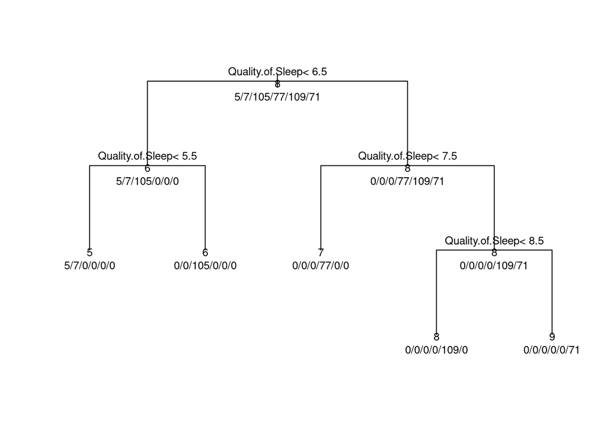

```r
library(rpart)
model = rpart(Y~.,data=data.frame(X),method="class")

plot(model,branch=1,uniform=T,xpd=NA)
text(model,fancy=F,all=T,use.n=T,cex=0.75,xpd=NA)
```

L’arbre de décision permet alors de représenter la repartition du jeu de données selon la qualité du sommeil. La branche ayant la meilleure qualité de sommeil se trouve sur la droite de l’arbre. `